# Risk Factor Analysis

## Outcome Variable

**Outcome Variable:** haz

## Predictor Variables

**Intervention Variable:** nrooms

**Adjustment Set:**

- arm
- sex
- W_mage
- meducyrs
- feducyrs
- hhwealth_quart
- hfoodsec
- W_mhtcm
- W_mwtkg
- W_mbmi
- W_nchldlt5
- W_parity
- impfloor
- impsan
- safeh20
- delta_W_mage
- delta_meducyrs
- delta_feducyrs
- delta_hhwealth_quart
- delta_hfoodsec
- delta_W_mhtcm
- delta_W_mwtkg
- delta_W_mbmi
- delta_W_nchldlt5
- delta_W_parity
- delta_impfloor
- delta_impsan
- delta_safeh20

## Stratifying Variables

The analysis was stratified on these variable(s):

- agecat
- studyid
- country

## Data Summary

| agecat | studyid | country | nrooms | n_cell | n | outcome_variable |
| --- | --- | --- | --- | --- | --- | --- |
| Birth | ki0047075b-MAL-ED | BANGLADESH | 4+ | 12 | 213 | haz |
| Birth | ki0047075b-MAL-ED | BANGLADESH | 1 | 130 | 213 | haz |
| Birth | ki0047075b-MAL-ED | BANGLADESH | 2 | 46 | 213 | haz |
| Birth | ki0047075b-MAL-ED | BANGLADESH | 3 | 25 | 213 | haz |
| Birth | ki0047075b-MAL-ED | BRAZIL | 4+ | 30 | 60 | haz |
| Birth | ki0047075b-MAL-ED | BRAZIL | 1 | 0 | 60 | haz |
| Birth | ki0047075b-MAL-ED | BRAZIL | 2 | 10 | 60 | haz |
| Birth | ki0047075b-MAL-ED | BRAZIL | 3 | 20 | 60 | haz |
| Birth | ki0047075b-MAL-ED | INDIA | 4+ | 2 | 41 | haz |
| Birth | ki0047075b-MAL-ED | INDIA | 1 | 18 | 41 | haz |
| Birth | ki0047075b-MAL-ED | INDIA | 2 | 17 | 41 | haz |
| Birth | ki0047075b-MAL-ED | INDIA | 3 | 4 | 41 | haz |
| Birth | ki0047075b-MAL-ED | NEPAL | 4+ | 15 | 26 | haz |
| Birth | ki0047075b-MAL-ED | NEPAL | 1 | 7 | 26 | haz |
| Birth | ki0047075b-MAL-ED | NEPAL | 2 | 2 | 26 | haz |
| Birth | ki0047075b-MAL-ED | NEPAL | 3 | 2 | 26 | haz |
| Birth | ki0047075b-MAL-ED | PERU | 4+ | 107 | 215 | haz |
| Birth | ki0047075b-MAL-ED | PERU | 1 | 13 | 215 | haz |
| Birth | ki0047075b-MAL-ED | PERU | 2 | 45 | 215 | haz |
| Birth | ki0047075b-MAL-ED | PERU | 3 | 50 | 215 | haz |
| Birth | ki0047075b-MAL-ED | SOUTH AFRICA | 4+ | 67 | 96 | haz |
| Birth | ki0047075b-MAL-ED | SOUTH AFRICA | 1 | 5 | 96 | haz |
| Birth | ki0047075b-MAL-ED | SOUTH AFRICA | 2 | 12 | 96 | haz |
| Birth | ki0047075b-MAL-ED | SOUTH AFRICA | 3 | 12 | 96 | haz |
| Birth | ki0047075b-MAL-ED | TANZANIA, UNITED REPUBLIC OF | 4+ | 49 | 120 | haz |
| Birth | ki0047075b-MAL-ED | TANZANIA, UNITED REPUBLIC OF | 1 | 9 | 120 | haz |
| Birth | ki0047075b-MAL-ED | TANZANIA, UNITED REPUBLIC OF | 2 | 31 | 120 | haz |
| Birth | ki0047075b-MAL-ED | TANZANIA, UNITED REPUBLIC OF | 3 | 31 | 120 | haz |
| Birth | ki1000108-CMC-V-BCS-2002 | INDIA | 4+ | 5 | 92 | haz |
| Birth | ki1000108-CMC-V-BCS-2002 | INDIA | 1 | 38 | 92 | haz |

[output cut: 162 more lines]

The following strata were considered:

- agecat: 24 months, studyid: ki0047075b-MAL-ED, country: BANGLADESH
- agecat: 24 months, studyid: ki0047075b-MAL-ED, country: BRAZIL
- agecat: 24 months, studyid: ki0047075b-MAL-ED, country: INDIA
- agecat: 24 months, studyid: ki0047075b-MAL-ED, country: NEPAL
- agecat: 24 months, studyid: ki0047075b-MAL-ED, country: PERU
- agecat: 24 months, studyid: ki0047075b-MAL-ED, country: SOUTH AFRICA
- agecat: 24 months, studyid: ki0047075b-MAL-ED, country: TANZANIA, UNITED REPUBLIC OF
- agecat: 24 months, studyid: ki1000108-CMC-V-BCS-2002, country: INDIA
- agecat: 24 months, studyid: ki1000108-IRC, country: INDIA
- agecat: 24 months, studyid: ki1017093b-PROVIDE, country: BANGLADESH
- agecat: 24 months, studyid: ki1017093c-NIH-Crypto, country: BANGLADESH
- agecat: 24 months, studyid: ki1113344-GMS-Nepal, country: NEPAL
- agecat: 24 months, studyid: ki1114097-CONTENT, country: PERU
- agecat: 24 months, studyid: ki1135781-COHORTS, country: INDIA
- agecat: 24 months, studyid: kiGH5241-JiVitA-3, country: BANGLADESH
- agecat: 24 months, studyid: kiGH5241-JiVitA-4, country: BANGLADESH
- agecat: 6 months, studyid: ki0047075b-MAL-ED, country: BANGLADESH
- agecat: 6 months, studyid: ki0047075b-MAL-ED, country: BRAZIL
- agecat: 6 months, studyid: ki0047075b-MAL-ED, country: INDIA
- agecat: 6 months, studyid: ki0047075b-MAL-ED, country: NEPAL
- agecat: 6 months, studyid: ki0047075b-MAL-ED, country: PERU
- agecat: 6 months, studyid: ki0047075b-MAL-ED, country: SOUTH AFRICA
- agecat: 6 months, studyid: ki0047075b-MAL-ED, country: TANZANIA, UNITED REPUBLIC OF
- agecat: 6 months, studyid: ki1000108-CMC-V-BCS-2002, country: INDIA
- agecat: 6 months, studyid: ki1000108-IRC, country: INDIA
- agecat: 6 months, studyid: ki1017093b-PROVIDE, country: BANGLADESH
- agecat: 6 months, studyid: ki1017093c-NIH-Crypto, country: BANGLADESH
- agecat: 6 months, studyid: ki1113344-GMS-Nepal, country: NEPAL
- agecat: 6 months, studyid: ki1114097-CONTENT, country: PERU
- agecat: 6 months, studyid: ki1135781-COHORTS, country: INDIA
- agecat: 6 months, studyid: kiGH5241-JiVitA-3, country: BANGLADESH
- agecat: 6 months, studyid: kiGH5241-JiVitA-4, country: BANGLADESH
- agecat: Birth, studyid: ki0047075b-MAL-ED, country: BANGLADESH
- agecat: Birth, studyid: ki0047075b-MAL-ED, country: BRAZIL
- agecat: Birth, studyid: ki0047075b-MAL-ED, country: INDIA
- agecat: Birth, studyid: ki0047075b-MAL-ED, country: NEPAL
- agecat: Birth, studyid: ki0047075b-MAL-ED, country: PERU
- agecat: Birth, studyid: ki0047075b-MAL-ED, country: SOUTH AFRICA
- agecat: Birth, studyid: ki0047075b-MAL-ED, country: TANZANIA, UNITED REPUBLIC OF
- agecat: Birth, studyid: ki1000108-CMC-V-BCS-2002, country: INDIA
- agecat: Birth, studyid: ki1000108-IRC, country: INDIA
- agecat: Birth, studyid: ki1017093b-PROVIDE, country: BANGLADESH
- agecat: Birth, studyid: ki1017093c-NIH-Crypto, country: BANGLADESH
- agecat: Birth, studyid: ki1113344-GMS-Nepal, country: NEPAL
- agecat: Birth, studyid: ki1114097-CONTENT, country: PERU
- agecat: Birth, studyid: ki1135781-COHORTS, country: INDIA
- agecat: Birth, studyid: kiGH5241-JiVitA-3, country: BANGLADESH
- agecat: Birth, studyid: kiGH5241-JiVitA-4, country: BANGLADESH

### Dropped Strata

Some strata were dropped due to rare outcomes:

- agecat: Birth, studyid: ki0047075b-MAL-ED, country: BRAZIL
- agecat: Birth, studyid: ki0047075b-MAL-ED, country: INDIA
- agecat: Birth, studyid: ki0047075b-MAL-ED, country: NEPAL
- agecat: Birth, studyid: ki1114097-CONTENT, country: PERU
- agecat: 6 months, studyid: ki0047075b-MAL-ED, country: BRAZIL
- agecat: 24 months, studyid: ki0047075b-MAL-ED, country: BRAZIL

## Methods Detail

We’re interested in the causal parameters $E[Y_a]$ for all values of $a \in \mathcal{A}$. These parameters represent the mean outcome if, possibly contrary to fact, we intervened to set all units to have $A=a$. Under the randomization and positivity assumptions, these are identified by the statistical parameters $\psi_a=E_W[E_{Y|A,W}(Y|A=a,W)]$. In addition, we’re interested in the mean of $Y$, $E[Y]$ under no intervention (the observed mean). We will estimate these parameters by using SuperLearner to fit the relevant likelihood factors – $E_{Y|A,W}(Y|A=a,W)$ and $p(A=a|W)$, and then updating our likelihood fit using a joint TMLE.

For unadjusted analyses ($W=\{\}$), initial likelihoods were estimated using Lrnr_glm to estimate the simple $E(Y|A)$ and Lrnr_mean to estimate $p(A)$. For adjusted analyses, a small library containing Lrnr_glmnet, Lrnr_xgboost, and Lrnr_mean was used.

# Results Detail

## Results Plots

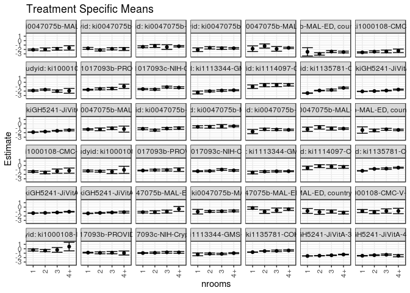

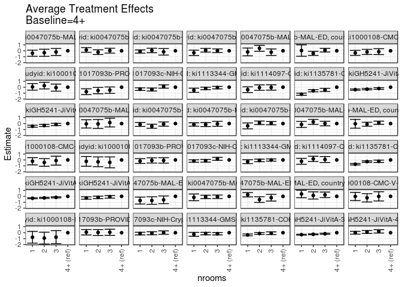

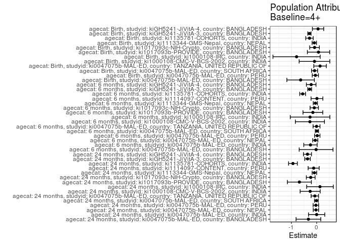

## Results Table

### Parameter: TSM

| agecat | studyid | country | intervention_level | baseline_level | estimate | ci_lower | ci_upper |
| --- | --- | --- | --- | --- | --- | --- | --- |
| Birth | ki0047075b-MAL-ED | BANGLADESH | 4+ | NA | -0.4181893 | -0.9761462 | 0.1397676 |
| Birth | ki0047075b-MAL-ED | BANGLADESH | 1 | NA | -1.1297178 | -1.3096661 | -0.9497694 |
| Birth | ki0047075b-MAL-ED | BANGLADESH | 2 | NA | -1.1240564 | -1.4199777 | -0.8281351 |
| Birth | ki0047075b-MAL-ED | BANGLADESH | 3 | NA | -1.0065516 | -1.3364072 | -0.6766961 |
| Birth | ki0047075b-MAL-ED | PERU | 4+ | NA | -0.8616050 | -1.0630403 | -0.6601697 |
| Birth | ki0047075b-MAL-ED | PERU | 1 | NA | -1.0296015 | -1.5547533 | -0.5044497 |
| Birth | ki0047075b-MAL-ED | PERU | 2 | NA | -0.9555812 | -1.1599209 | -0.7512416 |
| Birth | ki0047075b-MAL-ED | PERU | 3 | NA | -0.9306826 | -1.1421224 | -0.7192428 |
| Birth | ki0047075b-MAL-ED | SOUTH AFRICA | 4+ | NA | -0.4688060 | -0.7283817 | -0.2092303 |
| Birth | ki0047075b-MAL-ED | SOUTH AFRICA | 1 | NA | -0.1980000 | -0.4674799 | 0.0714799 |
| Birth | ki0047075b-MAL-ED | SOUTH AFRICA | 2 | NA | -1.0133333 | -1.4164289 | -0.6102377 |
| Birth | ki0047075b-MAL-ED | SOUTH AFRICA | 3 | NA | -0.7058333 | -1.2016555 | -0.2100111 |
| Birth | ki0047075b-MAL-ED | TANZANIA, UNITED REPUBLIC OF | 4+ | NA | -1.2567347 | -1.5615935 | -0.9518759 |
| Birth | ki0047075b-MAL-ED | TANZANIA, UNITED REPUBLIC OF | 1 | NA | -0.8588889 | -1.4085413 | -0.3092365 |
| Birth | ki0047075b-MAL-ED | TANZANIA, UNITED REPUBLIC OF | 2 | NA | -1.1070968 | -1.6324652 | -0.5817283 |
| Birth | ki0047075b-MAL-ED | TANZANIA, UNITED REPUBLIC OF | 3 | NA | -1.0022581 | -1.3571466 | -0.6473695 |
| Birth | ki1000108-CMC-V-BCS-2002 | INDIA | 4+ | NA | -0.8740000 | -1.4739904 | -0.2740096 |
| Birth | ki1000108-CMC-V-BCS-2002 | INDIA | 1 | NA | -0.8946053 | -1.2459292 | -0.5432813 |
| Birth | ki1000108-CMC-V-BCS-2002 | INDIA | 2 | NA | -1.1229310 | -1.4808250 | -0.7650370 |
| Birth | ki1000108-CMC-V-BCS-2002 | INDIA | 3 | NA | -0.8750000 | -1.3685904 | -0.3814096 |
| Birth | ki1000108-IRC | INDIA | 4+ | NA | 0.4878105 | -0.4714065 | 1.4470274 |
| Birth | ki1000108-IRC | INDIA | 1 | NA | -0.2772098 | -0.5178087 | -0.0366109 |
| Birth | ki1000108-IRC | INDIA | 2 | NA | -0.4127224 | -0.6677967 | -0.1576480 |
| Birth | ki1000108-IRC | INDIA | 3 | NA | -0.2545468 | -0.7920007 | 0.2829071 |
| Birth | ki1017093b-PROVIDE | BANGLADESH | 4+ | NA | -0.9586282 | -1.4081651 | -0.5090912 |
| Birth | ki1017093b-PROVIDE | BANGLADESH | 1 | NA | -0.8726644 | -0.9588316 | -0.7864972 |
| Birth | ki1017093b-PROVIDE | BANGLADESH | 2 | NA | -0.9207342 | -1.1370914 | -0.7043770 |
| Birth | ki1017093b-PROVIDE | BANGLADESH | 3 | NA | -0.8816814 | -1.1338704 | -0.6294924 |
| Birth | ki1017093c-NIH-Crypto | BANGLADESH | 4+ | NA | -0.8253428 | -1.0294832 | -0.6212023 |
| Birth | ki1017093c-NIH-Crypto | BANGLADESH | 1 | NA | -0.9656786 | -1.0643768 | -0.8669803 |

[output cut: 138 more lines]

### Parameter: E(Y)

| agecat | studyid | country | intervention_level | baseline_level | estimate | ci_lower | ci_upper |
| --- | --- | --- | --- | --- | --- | --- | --- |
| Birth | ki0047075b-MAL-ED | BANGLADESH | NA | NA | -1.0530516 | -1.1896058 | -0.9164975 |
| Birth | ki0047075b-MAL-ED | PERU | NA | NA | -0.9141395 | -1.0364098 | -0.7918693 |
| Birth | ki0047075b-MAL-ED | SOUTH AFRICA | NA | NA | -0.5523958 | -0.7550074 | -0.3497843 |
| Birth | ki0047075b-MAL-ED | TANZANIA, UNITED REPUBLIC OF | NA | NA | -1.1225000 | -1.3335666 | -0.9114334 |
| Birth | ki1000108-CMC-V-BCS-2002 | INDIA | NA | NA | -0.9611957 | -1.1776967 | -0.7446946 |
| Birth | ki1000108-IRC | INDIA | NA | NA | -0.3079016 | -0.4694769 | -0.1463262 |
| Birth | ki1017093b-PROVIDE | BANGLADESH | NA | NA | -0.8851020 | -0.9601332 | -0.8100709 |
| Birth | ki1017093c-NIH-Crypto | BANGLADESH | NA | NA | -0.9094945 | -0.9809370 | -0.8380521 |
| Birth | ki1113344-GMS-Nepal | NEPAL | NA | NA | -1.0851580 | -1.1651811 | -1.0051350 |
| Birth | ki1135781-COHORTS | INDIA | NA | NA | -0.6777626 | -0.7107167 | -0.6448086 |
| Birth | kiGH5241-JiVitA-3 | BANGLADESH | NA | NA | -1.5898426 | -1.6091216 | -1.5705636 |
| Birth | kiGH5241-JiVitA-4 | BANGLADESH | NA | NA | -1.5236135 | -1.5727559 | -1.4744711 |
| 6 months | ki0047075b-MAL-ED | BANGLADESH | NA | NA | -1.2026806 | -1.3203025 | -1.0850586 |
| 6 months | ki0047075b-MAL-ED | INDIA | NA | NA | -1.2070638 | -1.3255909 | -1.0885368 |
| 6 months | ki0047075b-MAL-ED | NEPAL | NA | NA | -0.5615819 | -0.6741832 | -0.4489807 |
| 6 months | ki0047075b-MAL-ED | PERU | NA | NA | -1.3248549 | -1.4336721 | -1.2160378 |
| 6 months | ki0047075b-MAL-ED | SOUTH AFRICA | NA | NA | -1.0547925 | -1.1843544 | -0.9252306 |
| 6 months | ki0047075b-MAL-ED | TANZANIA, UNITED REPUBLIC OF | NA | NA | -1.3687449 | -1.4907629 | -1.2467270 |
| 6 months | ki1000108-CMC-V-BCS-2002 | INDIA | NA | NA | -1.4234508 | -1.5645974 | -1.2823042 |
| 6 months | ki1000108-IRC | INDIA | NA | NA | -1.2470123 | -1.3779341 | -1.1160906 |
| 6 months | ki1017093b-PROVIDE | BANGLADESH | NA | NA | -1.0916915 | -1.1661176 | -1.0172654 |
| 6 months | ki1017093c-NIH-Crypto | BANGLADESH | NA | NA | -1.1986783 | -1.2700937 | -1.1272630 |
| 6 months | ki1113344-GMS-Nepal | NEPAL | NA | NA | -1.3508392 | -1.4290633 | -1.2726152 |
| 6 months | ki1114097-CONTENT | PERU | NA | NA | -0.3139217 | -0.4868486 | -0.1409948 |
| 6 months | ki1135781-COHORTS | INDIA | NA | NA | -1.0413281 | -1.0740395 | -1.0086167 |
| 6 months | kiGH5241-JiVitA-3 | BANGLADESH | NA | NA | -1.3132988 | -1.3364412 | -1.2901565 |
| 6 months | kiGH5241-JiVitA-4 | BANGLADESH | NA | NA | -1.3440477 | -1.3813060 | -1.3067894 |
| 24 months | ki0047075b-MAL-ED | BANGLADESH | NA | NA | -1.9783962 | -2.1050210 | -1.8517715 |
| 24 months | ki0047075b-MAL-ED | INDIA | NA | NA | -1.8861894 | -2.0110006 | -1.7613783 |
| 24 months | ki0047075b-MAL-ED | NEPAL | NA | NA | -1.3075877 | -1.4270718 | -1.1881037 |
| 24 months | ki0047075b-MAL-ED | PERU | NA | NA | -1.7524710 | -1.8736426 | -1.6312994 |
| 24 months | ki0047075b-MAL-ED | SOUTH AFRICA | NA | NA | -1.6450595 | -1.7797240 | -1.5103950 |
| 24 months | ki0047075b-MAL-ED | TANZANIA, UNITED REPUBLIC OF | NA | NA | -2.6455607 | -2.7807256 | -2.5103959 |
| 24 months | ki1000108-CMC-V-BCS-2002 | INDIA | NA | NA | -2.5588679 | -2.6583730 | -2.4593629 |
| 24 months | ki1000108-IRC | INDIA | NA | NA | -1.8014906 | -1.8952579 | -1.7077232 |
| 24 months | ki1017093b-PROVIDE | BANGLADESH | NA | NA | -1.6024221 | -1.6857420 | -1.5191023 |
| 24 months | ki1017093c-NIH-Crypto | BANGLADESH | NA | NA | -1.4412646 | -1.5249156 | -1.3576135 |
| 24 months | ki1113344-GMS-Nepal | NEPAL | NA | NA | -1.8874180 | -1.9728588 | -1.8019773 |
| 24 months | ki1114097-CONTENT | PERU | NA | NA | -0.6962195 | -0.8674103 | -0.5250287 |
| 24 months | ki1135781-COHORTS | INDIA | NA | NA | -2.2131714 | -2.2523749 | -2.1739679 |
| 24 months | kiGH5241-JiVitA-3 | BANGLADESH | NA | NA | -2.0137471 | -2.0414306 | -1.9860636 |
| 24 months | kiGH5241-JiVitA-4 | BANGLADESH | NA | NA | -1.7803708 | -1.8158650 | -1.7448765 |

### Parameter: ATE

| agecat | studyid | country | intervention_level | baseline_level | estimate | ci_lower | ci_upper |
| --- | --- | --- | --- | --- | --- | --- | --- |
| Birth | ki0047075b-MAL-ED | BANGLADESH | 4+ | 4+ | 0.0000000 | 0.0000000 | 0.0000000 |
| Birth | ki0047075b-MAL-ED | BANGLADESH | 1 | 4+ | -0.7115284 | -1.2979473 | -0.1251096 |
| Birth | ki0047075b-MAL-ED | BANGLADESH | 2 | 4+ | -0.7058671 | -1.3375257 | -0.0742085 |
| Birth | ki0047075b-MAL-ED | BANGLADESH | 3 | 4+ | -0.5883623 | -1.2366742 | 0.0599496 |
| Birth | ki0047075b-MAL-ED | PERU | 4+ | 4+ | 0.0000000 | 0.0000000 | 0.0000000 |
| Birth | ki0047075b-MAL-ED | PERU | 1 | 4+ | -0.1679965 | -0.7297476 | 0.3937546 |
| Birth | ki0047075b-MAL-ED | PERU | 2 | 4+ | -0.0939762 | -0.3789989 | 0.1910464 |
| Birth | ki0047075b-MAL-ED | PERU | 3 | 4+ | -0.0690776 | -0.3600580 | 0.2219028 |
| Birth | ki0047075b-MAL-ED | SOUTH AFRICA | 4+ | 4+ | 0.0000000 | 0.0000000 | 0.0000000 |
| Birth | ki0047075b-MAL-ED | SOUTH AFRICA | 1 | 4+ | 0.2708060 | -0.1033584 | 0.6449703 |
| Birth | ki0047075b-MAL-ED | SOUTH AFRICA | 2 | 4+ | -0.5445274 | -1.0239704 | -0.0650843 |
| Birth | ki0047075b-MAL-ED | SOUTH AFRICA | 3 | 4+ | -0.2370274 | -0.7966873 | 0.3226325 |
| Birth | ki0047075b-MAL-ED | TANZANIA, UNITED REPUBLIC OF | 4+ | 4+ | 0.0000000 | 0.0000000 | 0.0000000 |
| Birth | ki0047075b-MAL-ED | TANZANIA, UNITED REPUBLIC OF | 1 | 4+ | 0.3978458 | -0.2306895 | 1.0263811 |
| Birth | ki0047075b-MAL-ED | TANZANIA, UNITED REPUBLIC OF | 2 | 4+ | 0.1496379 | -0.4577754 | 0.7570512 |
| Birth | ki0047075b-MAL-ED | TANZANIA, UNITED REPUBLIC OF | 3 | 4+ | 0.2544766 | -0.2133746 | 0.7223279 |
| Birth | ki1000108-CMC-V-BCS-2002 | INDIA | 4+ | 4+ | 0.0000000 | 0.0000000 | 0.0000000 |
| Birth | ki1000108-CMC-V-BCS-2002 | INDIA | 1 | 4+ | -0.0206053 | -0.7158872 | 0.6746767 |
| Birth | ki1000108-CMC-V-BCS-2002 | INDIA | 2 | 4+ | -0.2489310 | -0.9475558 | 0.4496938 |
| Birth | ki1000108-CMC-V-BCS-2002 | INDIA | 3 | 4+ | -0.0010000 | -0.7779299 | 0.7759299 |
| Birth | ki1000108-IRC | INDIA | 4+ | 4+ | 0.0000000 | 0.0000000 | 0.0000000 |
| Birth | ki1000108-IRC | INDIA | 1 | 4+ | -0.7650203 | -1.7546827 | 0.2246422 |
| Birth | ki1000108-IRC | INDIA | 2 | 4+ | -0.9005328 | -1.8941286 | 0.0930629 |
| Birth | ki1000108-IRC | INDIA | 3 | 4+ | -0.7423572 | -1.8436087 | 0.3588943 |
| Birth | ki1017093b-PROVIDE | BANGLADESH | 4+ | 4+ | 0.0000000 | 0.0000000 | 0.0000000 |
| Birth | ki1017093b-PROVIDE | BANGLADESH | 1 | 4+ | 0.0859638 | -0.3724809 | 0.5444086 |
| Birth | ki1017093b-PROVIDE | BANGLADESH | 2 | 4+ | 0.0378940 | -0.4623768 | 0.5381648 |
| Birth | ki1017093b-PROVIDE | BANGLADESH | 3 | 4+ | 0.0769468 | -0.4396835 | 0.5935770 |
| Birth | ki1017093c-NIH-Crypto | BANGLADESH | 4+ | 4+ | 0.0000000 | 0.0000000 | 0.0000000 |
| Birth | ki1017093c-NIH-Crypto | BANGLADESH | 1 | 4+ | -0.1403358 | -0.3668960 | 0.0862243 |

[output cut: 138 more lines]

### Parameter: PAR

| agecat | studyid | country | intervention_level | baseline_level | estimate | ci_lower | ci_upper |
| --- | --- | --- | --- | --- | --- | --- | --- |
| Birth | ki0047075b-MAL-ED | BANGLADESH | 4+ | NA | -0.6348623 | -1.1794898 | -0.0902349 |
| Birth | ki0047075b-MAL-ED | PERU | 4+ | NA | -0.0525345 | -0.1756460 | 0.0705769 |
| Birth | ki0047075b-MAL-ED | SOUTH AFRICA | 4+ | NA | -0.0835899 | -0.2035080 | 0.0363283 |
| Birth | ki0047075b-MAL-ED | TANZANIA, UNITED REPUBLIC OF | 4+ | NA | 0.1342347 | -0.1139344 | 0.3824038 |
| Birth | ki1000108-CMC-V-BCS-2002 | INDIA | 4+ | NA | -0.0871957 | -0.6936048 | 0.5192134 |
| Birth | ki1000108-IRC | INDIA | 4+ | NA | -0.7957120 | -1.7301792 | 0.1387552 |
| Birth | ki1017093b-PROVIDE | BANGLADESH | 4+ | NA | 0.0735261 | -0.3679714 | 0.5150237 |
| Birth | ki1017093c-NIH-Crypto | BANGLADESH | 4+ | NA | -0.0841518 | -0.2751735 | 0.1068699 |
| Birth | ki1113344-GMS-Nepal | NEPAL | 4+ | NA | -0.0941675 | -0.1808499 | -0.0074851 |
| Birth | ki1135781-COHORTS | INDIA | 4+ | NA | -0.2841839 | -0.4319608 | -0.1364069 |
| Birth | kiGH5241-JiVitA-3 | BANGLADESH | 4+ | NA | -0.2871227 | -0.3513285 | -0.2229169 |
| Birth | kiGH5241-JiVitA-4 | BANGLADESH | 4+ | NA | 0.0545904 | -0.1693200 | 0.2785008 |
| 6 months | ki0047075b-MAL-ED | BANGLADESH | 4+ | NA | -0.0228367 | -0.6914186 | 0.6457451 |
| 6 months | ki0047075b-MAL-ED | INDIA | 4+ | NA | -0.2455353 | -0.5104676 | 0.0193970 |
| 6 months | ki0047075b-MAL-ED | NEPAL | 4+ | NA | -0.0563662 | -0.1576905 | 0.0449581 |
| 6 months | ki0047075b-MAL-ED | PERU | 4+ | NA | 0.0238985 | -0.0830529 | 0.1308498 |
| 6 months | ki0047075b-MAL-ED | SOUTH AFRICA | 4+ | NA | 0.0095632 | -0.0548802 | 0.0740065 |
| 6 months | ki0047075b-MAL-ED | TANZANIA, UNITED REPUBLIC OF | 4+ | NA | -0.0052664 | -0.1424330 | 0.1319002 |
| 6 months | ki1000108-CMC-V-BCS-2002 | INDIA | 4+ | NA | -0.2672992 | -0.8432566 | 0.3086582 |
| 6 months | ki1000108-IRC | INDIA | 4+ | NA | -0.2622186 | -1.0458930 | 0.5214559 |
| 6 months | ki1017093b-PROVIDE | BANGLADESH | 4+ | NA | -0.1504112 | -0.5414997 | 0.2406773 |
| 6 months | ki1017093c-NIH-Crypto | BANGLADESH | 4+ | NA | -0.0954707 | -0.2614044 | 0.0704631 |
| 6 months | ki1113344-GMS-Nepal | NEPAL | 4+ | NA | -0.0516055 | -0.1345009 | 0.0312899 |
| 6 months | ki1114097-CONTENT | PERU | 4+ | NA | 0.0105059 | -0.2235948 | 0.2446065 |
| 6 months | ki1135781-COHORTS | INDIA | 4+ | NA | -0.5559200 | -0.6704075 | -0.4414324 |
| 6 months | kiGH5241-JiVitA-3 | BANGLADESH | 4+ | NA | -0.2767149 | -0.3522102 | -0.2012196 |
| 6 months | kiGH5241-JiVitA-4 | BANGLADESH | 4+ | NA | -0.2174525 | -0.4075290 | -0.0273760 |
| 24 months | ki0047075b-MAL-ED | BANGLADESH | 4+ | NA | -0.3271128 | -0.8162598 | 0.1620341 |
| 24 months | ki0047075b-MAL-ED | INDIA | 4+ | NA | -0.0014549 | -0.3231928 | 0.3202829 |
| 24 months | ki0047075b-MAL-ED | NEPAL | 4+ | NA | -0.0294893 | -0.1358901 | 0.0769114 |
| 24 months | ki0047075b-MAL-ED | PERU | 4+ | NA | -0.0316242 | -0.1403842 | 0.0771358 |
| 24 months | ki0047075b-MAL-ED | SOUTH AFRICA | 4+ | NA | -0.0118941 | -0.0865671 | 0.0627790 |
| 24 months | ki0047075b-MAL-ED | TANZANIA, UNITED REPUBLIC OF | 4+ | NA | -0.0733158 | -0.2199439 | 0.0733122 |
| 24 months | ki1000108-CMC-V-BCS-2002 | INDIA | 4+ | NA | -0.2582449 | -0.6552543 | 0.1387644 |
| 24 months | ki1000108-IRC | INDIA | 4+ | NA | 0.1302721 | -0.3967683 | 0.6573124 |
| 24 months | ki1017093b-PROVIDE | BANGLADESH | 4+ | NA | -0.6839537 | -1.1586842 | -0.2092232 |
| 24 months | ki1017093c-NIH-Crypto | BANGLADESH | 4+ | NA | -0.2358266 | -0.4091498 | -0.0625034 |
| 24 months | ki1113344-GMS-Nepal | NEPAL | 4+ | NA | -0.0898911 | -0.1792481 | -0.0005342 |
| 24 months | ki1114097-CONTENT | PERU | 4+ | NA | -0.1199344 | -0.3386677 | 0.0987988 |
| 24 months | ki1135781-COHORTS | INDIA | 4+ | NA | -0.9392249 | -1.1126536 | -0.7657963 |
| 24 months | kiGH5241-JiVitA-3 | BANGLADESH | 4+ | NA | -0.3613346 | -0.4710845 | -0.2515848 |
| 24 months | kiGH5241-JiVitA-4 | BANGLADESH | 4+ | NA | -0.3637035 | -0.5221533 | -0.2052537 |